# Необходимая величина подогрева входного воздуха КВОУ ГТУ. Часть 2.

В [1] приведён пример расчёта необходимой величины нагрева воздуха для предотвращения обледенения элементов входного тракта компрессора ГТУ где искалась величина нагрева воздуха при которой температура поверхности входных элементов компрессора поднималась выше температуры точки росы.

Теперь мы разработаем алгоритм работы системы подогрева воздуха КВОУ, основанный на требованиях производителя ГТУ касательно условий её включения.

Система подогрева воздуха КВОУ должна включаться при одновременном выполнении следующих условий:

1. Температура наружного воздуха находится в диапазоне $[- 5^\circ С; + 5^\circ С]$;
2. Относительная влажность наружного воздуха выше $80\%$.

Отключение системы подогрева воздуха КВОУ будет происходить при выполнении одного из следующих условий:

1. Температура наружного воздуха выше $+7^\circ С$ или ниже $-7^\circ С$;
2. Относительная влажность наружного воздуха ниже $70 \%$.

Самый простой алгоритм работы системы подогрева воздуха - это при возникновении условий её включения нагревать воздух до температуры выше $+5^\circ С$ (например, до $+7^\circ С$).

Также рассмотрим вариант нагрева воздуха до температуры, при которой его относительная влажность снизится до менее $80\%$ (в нашем примере до $70\%$).

Относительная влажность ($RH$ - relative humidity) - это отношение парциального давления входящего в состав влажного воздуха водяного пара $p_{в.п.}$ к давлению насыщения водяного пара $p_{нас}$ при заданной температуре: $RH = p_{в.п.}/p_{нас}$.

Так как $p_{в.п.}$ не зависит от температуры, а $p_{нас}$ с повышением температуры увеличивается, то при нагреве влажного воздуха его относительная влажность снижается.

Для расчётов использовался модуль `wetairprops` (см. [2]).

```python
from wetairprops import calc_d, calc_RH_d
import numpy as np
from scipy.optimize import root_scalar
```

```python
RH_ц = 0.7  # целевое значение относительной влажности до которого должен нагреваться воздух
ts = np.linspace(-5, 5)  # исследуемый диапазон температур
RHs = np.array([0.8, 0.85, 0.9, 0.95, 1.])  # значения относительной влажности воздуха
```

```python
# Функция для передачи в root_scalar
# Возвращает ноль когда при заданных t и d RH = 70%
def f(t, d):
    return calc_RH_d(t, d) - RH_ц
```

```python
# Определим необходимую величину нагрева воздуха для раличных значений температуры
# и относительной влажности
dts = np.zeros((len(ts), len(RHs)))
for i, t in enumerate(ts):
    for j, RH in enumerate(RHs):
        d = calc_d(t, RH)
        sol = root_scalar(f, (d), bracket = [t, t+10])
        dts[i, j] = sol.root - t
```

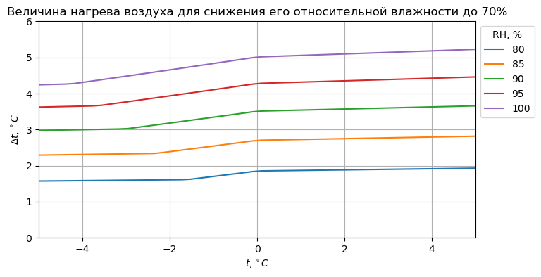

```python
# Построим график
import matplotlib.pyplot as plt
fig, ax = plt.subplots(figsize = (8, 4))
ax.set_title('Величина нагрева воздуха для снижения его относительной влажности до 70%')
ax.label = RHs
ax.set_xlabel('$t,^\circ C$'); ax.set_ylabel('$\Delta t,^\circ C$')
ax.plot(ts, dts)
ax.legend(np.int_(RHs * 100), title = 'RH, %', bbox_to_anchor=(1, 1))
ax.set_xlim(ts[0], ts[-1]); ax.set_ylim(0, 6); ax.grid()
```

Причиной появления изломов на вышеприведённых графиках является то, что зависимость упругости водяных паров от температуры для отрицательных и положительных температур воздуха описывается разными формулами. Изломы появляются при $t = 0 ^\circ C$ и $t = - \Delta t$.

Из графиков видно, что наибольшая требуемая величина нагрева воздуха соответствует температуре воздуха $t = +5^\circ C$.

```python
# Для каждого значения относительной влажности найдём максимальное значение
# величины нагрева воздуха
dts_max = [max(dts[:, i]) for i in range(len(RHs))]
```

Построим зависимость требуемой величины нагрева воздуха от его относительной влажности при которой относительная влажность воздуха после его нагрева снижается до $70\%$ и ниже.

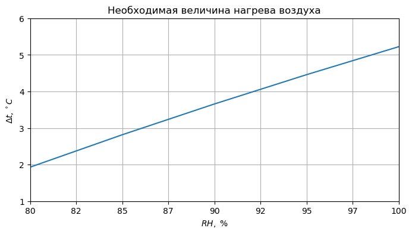

```python
fig, ax = plt.subplots(figsize = (8, 4))
from matplotlib.ticker import FormatStrFormatter
ax.set_title('Необходимая величина нагрева воздуха')
ax.set_xlabel('$RH,\ \%$'); ax.set_ylabel('$\Delta t,^\circ C$')
ax.plot(RHs * 100, dts_max)
ax.xaxis.set_major_formatter(FormatStrFormatter('%d'))
ax.set_xlim(RHs[0] * 100, RHs[-1] * 100); ax.set_ylim(1, 6); ax.grid()
```

Примем (с запасом), что при относительной влажности воздуха $RH = 80\%$ он должен нагреваться на $3^\circ С$, а при $RH = 100\%$ - на $6^\circ С$. Тогда формула для определения требуемой величины нагрева наружного воздуха в зависимости от его относительной влажности примет следующий вид:

$\Delta t = 3 + (6 - 3) / (100 - 80) \cdot (RH - 80)$

Согласно данной формуле при $RH = 70\%$ (значение при достижении которого система подогрева воздуха КВОУ отключается) величина подогрева составит $\Delta t = 1.5 ^\circ С$.

При температуре наружного воздуха $t = +5 ^\circ С$ и его относительной влажности $RH = 100\%$ по первому (простому) алгоритму работы системы подогрева воздуха его нужно нагреть на 2 градуса, а по второму алгоритму - на 6 градусов.

С увеличением температуры воздуха, поступающего в компрессор ГТУ, мощность и КПД ГТУ уменьшаются, поэтому лучше не нагревать воздух сверх необходимой для недопущения обледенения величины.

Следует определять величину подогрева воздуха по обоим алгоритмам и выбирать наименьшее значение:

$\Delta t = min(\Delta t_{t7}; \Delta t_{RH70})$,

где $\Delta t_{t7}$ - величина нагрева воздуха до температуры $t = 7^\circ С$, $\Delta t_{RH70}$ - величина нагрева воздуха до относительной влажности $70\%$.

### Ссылки

1. [Необходимая величина подогрева входного воздуха КВОУ ГТУ](https://medsv.github.io/dzen/0038/APH.html)
2. [Модуль для расчёта свойств влажного воздуха](https://medsv.github.io/dzen/0048/wetairprops.html)

[Инженерные расчёты на Python](https://zen.yandex.ru/id/5f33dcd5554adc5b33aaee83), С.В. Медведев, 2020-2023  
[Использование Python и Jupyter Notebook для инженерных расчётов](https://medsv.github.io/dzen/), С.В. Медведев, 2020-2023